# AnSeq_groupProject

## Fitting

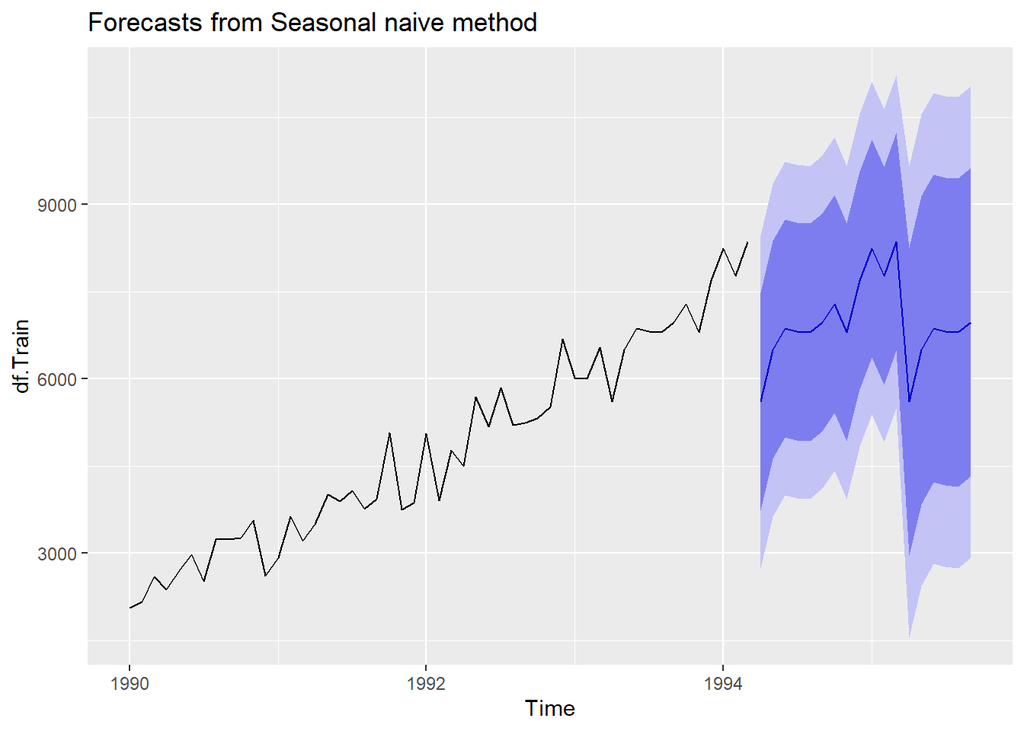

```r
autoplot(snaive_shipment)
```

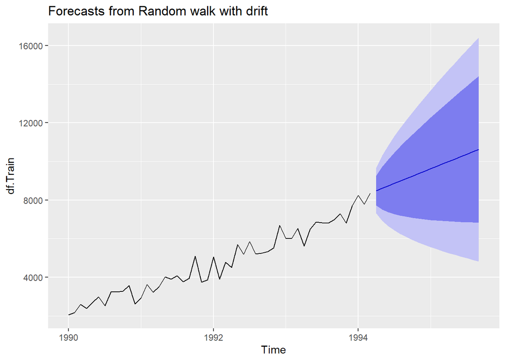

```r
autoplot(rwf_shipment)
```

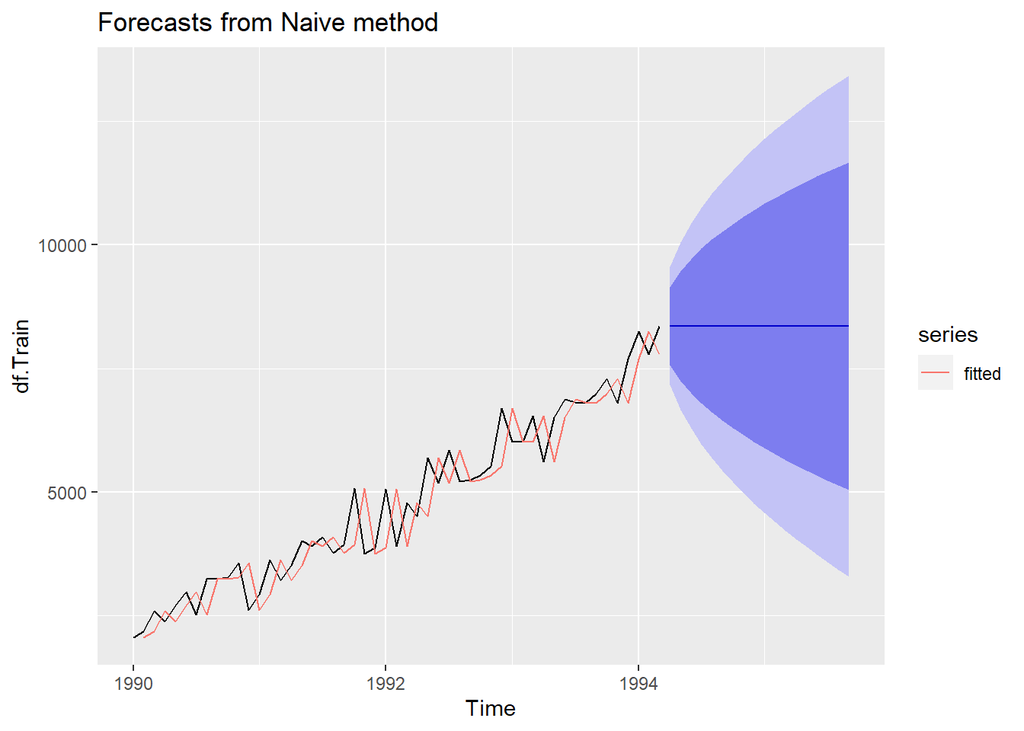

```r
autoplot(naive_shipment)+autolayer(fitted(naive_shipment), series = "fitted")
```

```r
summary(naive_shipment)
```

```
##
## Forecast method: Naive method
##
## Model Information:
## Call: naive(y = df.Train, h = length(df.Test))
##
## Residual sd: 610.2065
##
## Error measures:
##               ME     RMSE   MAE      MPE     MAPE      MASE       ACF1
## Training set 126 610.2065 487.2 1.853727 10.80512 0.3624723 -0.5517306
##
## Forecasts:
##          Point Forecast    Lo 80     Hi 80    Lo 95     Hi 95
## Apr 1994           8360 7577.989  9142.011 7164.017  9555.983
## May 1994           8360 7254.069  9465.931 6668.625 10051.375
## Jun 1994           8360 7005.517  9714.483 6288.497 10431.503
## Jul 1994           8360 6795.978  9924.022 5968.034 10751.966
## Aug 1994           8360 6611.370 10108.630 5685.701 11034.299
## Sep 1994           8360 6444.472 10275.528 5430.452 11289.548
## Oct 1994           8360 6290.993 10429.007 5195.727 11524.273
## Nov 1994           8360 6148.139 10571.861 4977.250 11742.750
## Dec 1994           8360 6013.967 10706.033 4772.052 11947.948
## Jan 1995           8360 5887.064 10832.936 4577.970 12142.030
## Feb 1995           8360 5766.363 10953.637 4393.374 12326.626
## Mar 1995           8360 5651.034 11068.966 4216.994 12503.006
## Apr 1995           8360 5540.419 11179.581 4047.823 12672.177
## May 1995           8360 5433.982 11286.018 3885.042 12834.958
## Jun 1995           8360 5331.284 11388.716 3727.979 12992.021
## Jul 1995           8360 5231.956 11488.044 3576.069 13143.931
## Aug 1995           8360 5135.686 11584.314 3428.837 13291.163
## Sep 1995           8360 5042.208 11677.792 3285.875 13434.125
```

```r
summary(snaive_shipment)
```

```
##
## Forecast method: Seasonal naive method
##
## Model Information:
## Call: snaive(y = df.Train, h = length(df.Test))
##
## Residual sd: 1461.9481
##
## Error measures:
##                    ME     RMSE      MAE      MPE     MAPE MASE       ACF1
## Training set 1344.103 1461.948 1344.103 24.81859 24.81859    1 -0.1477785
##
## Forecasts:
##          Point Forecast    Lo 80     Hi 80    Lo 95     Hi 95
## Apr 1994           5610 3736.438  7483.562 2744.634  8475.366
## May 1994           6500 4626.438  8373.562 3634.634  9365.366
## Jun 1994           6870 4996.438  8743.562 4004.634  9735.366
## Jul 1994           6820 4946.438  8693.562 3954.634  9685.366
## Aug 1994           6800 4926.438  8673.562 3934.634  9665.366
## Sep 1994           6980 5106.438  8853.562 4114.634  9845.366
## Oct 1994           7290 5416.438  9163.562 4424.634 10155.366
## Nov 1994           6800 4926.438  8673.562 3934.634  9665.366
## Dec 1994           7700 5826.438  9573.562 4834.634 10565.366
## Jan 1995           8250 6376.438 10123.562 5384.634 11115.366
## Feb 1995           7780 5906.438  9653.562 4914.634 10645.366
## Mar 1995           8360 6486.438 10233.562 5494.634 11225.366
## Apr 1995           5610 2960.383  8259.617 1557.761  9662.239
## May 1995           6500 3850.383  9149.617 2447.761 10552.239
## Jun 1995           6870 4220.383  9519.617 2817.761 10922.239
## Jul 1995           6820 4170.383  9469.617 2767.761 10872.239
## Aug 1995           6800 4150.383  9449.617 2747.761 10852.239
## Sep 1995           6980 4330.383  9629.617 2927.761 11032.239
```

```r
summary(rwf_shipment)
```

```
##
## Forecast method: Random walk with drift
##
## Model Information:
## Call: rwf(y = df.Train, h = length(df.Test), drift = TRUE)
##
## Drift: 126  (se 85.2937)
## Residual sd: 603.1178
##
## Error measures:
##              ME     RMSE    MAE       MPE     MAPE     MASE       ACF1
## Training set  0 597.0561 466.96 -1.086826 10.41201 0.347414 -0.5517306
##
## Forecasts:
##          Point Forecast    Lo 80     Hi 80    Lo 95     Hi 95
## Apr 1994           8486 7713.074  9258.926 7303.911  9668.089
## May 1994           8612 7508.040  9715.960 6923.639 10300.361
## Jun 1994           8738 7372.740 10103.260 6650.014 10825.986
## Jul 1994           8864 7272.447 10455.553 6429.930 11298.070
## Aug 1994           8990 7193.881 10786.119 6243.073 11736.927
## Sep 1994           9116 7130.316 11101.684 6079.158 12152.842
## Oct 1994           9242 7077.806 11406.194 5932.151 12551.849
## Nov 1994           9368 7033.813 11702.187 5798.169 12937.831
## Dec 1994           9494 6996.598 11991.402 5674.553 13313.447
## Jan 1995           9620 6964.910 12275.090 5559.391 13680.609
## Feb 1995           9746 6937.819 12554.181 5451.257 14040.743
## Mar 1995           9872 6914.609 12829.391 5349.061 14394.939
## Apr 1995           9998 6894.722 13101.278 5251.946 14744.054
## May 1995          10124 6877.709 13370.291 5159.226 15088.774
## Jun 1995          10250 6863.206 13636.794 5070.345 15429.655
## Jul 1995          10376 6850.913 13901.087 4984.844 15767.156
## Aug 1995          10502 6840.579 14163.421 4902.340 16101.660
## Sep 1995          10628 6831.994 14424.006 4822.510 16433.490
```

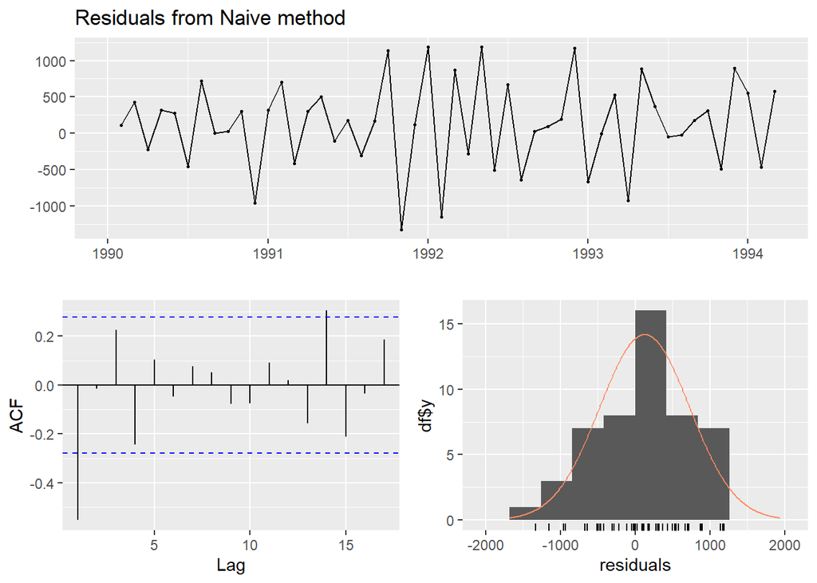

```
##
##  Ljung-Box test
##
## data:  Residuals from Naive method
## Q* = 24.348, df = 10, p-value = 0.006729
##
## Model df: 0.   Total lags used: 10
```

```r
checkresiduals(naive_shipment)
```

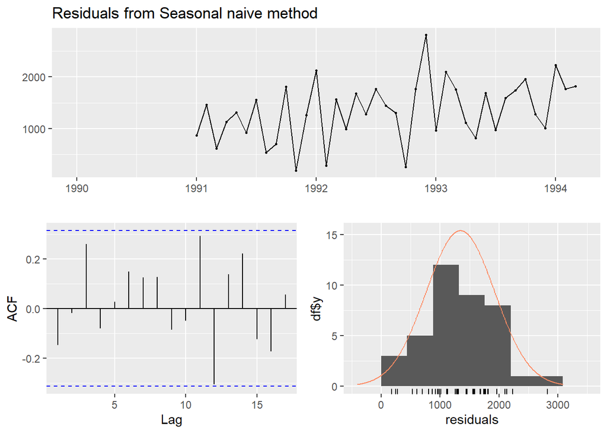

```
##
##  Ljung-Box test
##
## data:  Residuals from Seasonal naive method
## Q* = 7.4828, df = 10, p-value = 0.6792
##
## Model df: 0.   Total lags used: 10
```

```r
checkresiduals(snaive_shipment)
```

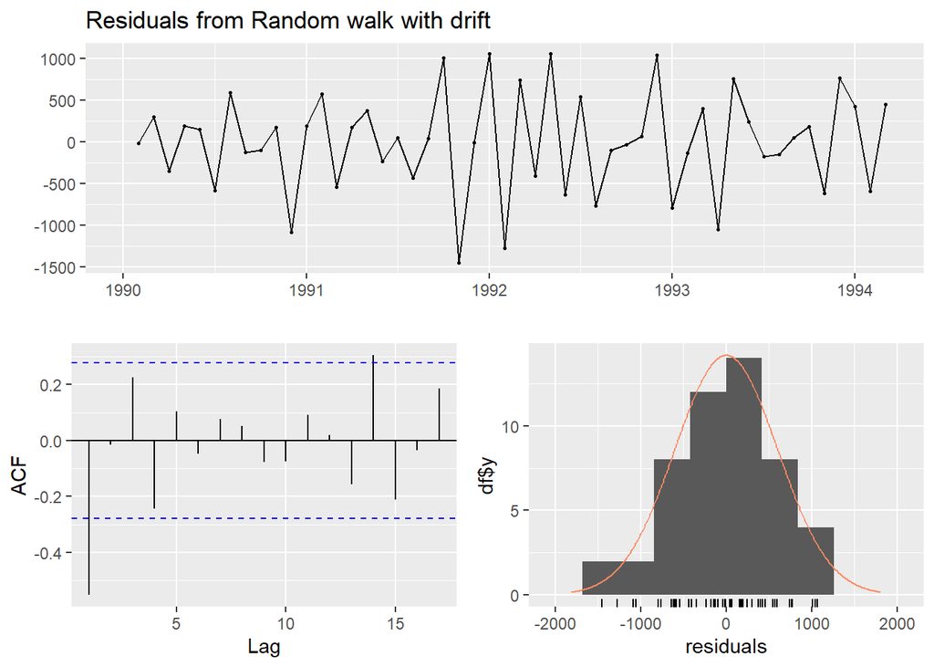

```
##
##  Ljung-Box test
##
## data:  Residuals from Random walk with drift
## Q* = 24.348, df = 9, p-value = 0.003784
##
## Model df: 1.   Total lags used: 10
```

```r
checkresiduals(rwf_shipment)
```

# Exponential Smoothing (Kevin)

## Analysis

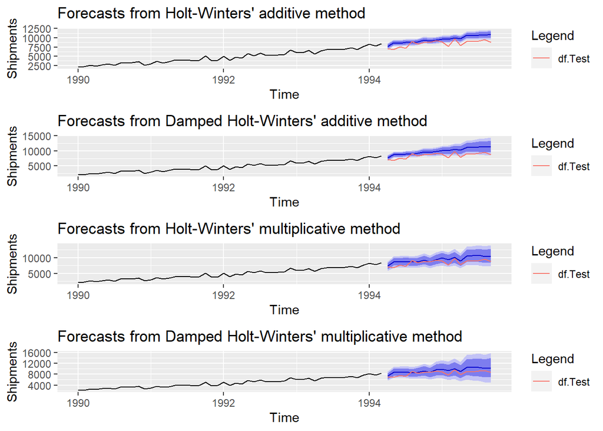

```r
df.hwAdd <- hw(df.Train, seasonal = "additive", h = length(df.Test))
df.hwAddDamped <- hw(df.Train, seasonal = "additive", damped = TRUE, h = length(df.Test))
df.hwMulti <- hw(df.Train, seasonal = "multiplicative", h = length(df.Test))
df.hwMultiDamped <- hw(df.Train, seasonal = "multiplicative", damped = TRUE, h = length(df.Test))

#plot

df.hwAddPlot <- autoplot(df.hwAdd, color="AdditiveMethod") +
  labs(x="Time", y="Shipments", color = "Legend") +
  autolayer(df.Test)

df.hwAddDampedPlot <- autoplot(df.hwAddDamped, color="AdditiveMethod") +
  labs(x="Time", y="Shipments", color = "Legend") +
  autolayer(df.Test)

df.hwMultiPlot <- autoplot(df.hwMulti, color="MultiMethod") +
  labs(x="Time", y="Shipments", color = "Legend") +
  autolayer(df.Test)

df.hwMultiDampedPlot <- autoplot(df.hwMultiDamped, color="MultiMethod") +
  labs(x="Time", y="Shipments", color = "Legend") +
  autolayer(df.Test)

grid.arrange(df.hwAddPlot, df.hwAddDampedPlot,  df.hwMultiPlot, df.hwMultiDampedPlot, nrow=4)
```

As can be seen from the above plots, the Damped Holt-Winter’s multiplicative Method seems to show a similar forecast to the test set. Before evaluating the accuracy we want to check the residuals.

#### Residuals

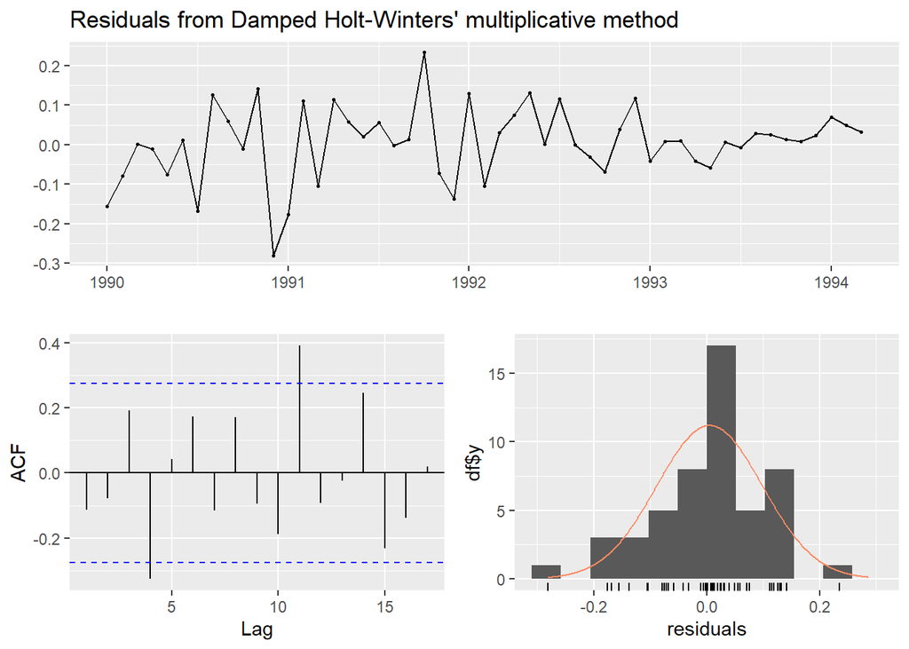

```
##
##  Ljung-Box test
##
## data:  Residuals from Damped Holt-Winters' multiplicative method
## Q* = 38.801, df = 3, p-value = 1.912e-08
##
## Model df: 17.   Total lags used: 20
```

```r
checkresiduals(df.hwMultiDamped)
```

The Ljung-Box test shows a p-value << 0.05 and therefore the NUll-Hypothesis is rejected. The residuals might be auto-correlated.

From the ACF a pattern is difficult to detect but s significant-autocorrelation is shown at lag 4 and 11. R12 is small and indicates no seasonality.

Accuracy of the fitted values for the training data

```r
accDf <- rbind(
  accuracy(df.hwAdd$fitted, df.Train),
  accuracy(df.hwAddDamped$fitted, df.Train),
  accuracy(df.hwMulti$fitted, df.Train),
  accuracy(df.hwMultiDamped$fitted, df.Train)
)
rownames(accDf) <- c("hw Additive", "hw damped Additive", "hw Multiplicative", "hw damped Multiplicative")

print(accDf)
```

```
##                                ME     RMSE      MAE        MPE     MAPE
## hw Additive              72.10311 365.9992 294.5030  0.7922975 6.779857
## hw damped Additive       52.63702 393.5663 305.9258 -0.1458775 7.074646
## hw Multiplicative        32.44569 357.3381 266.5627 -0.4580946 6.532985
## hw damped Multiplicative 45.14048 377.8383 290.0058 -0.4344784 7.049751
##                                 ACF1 Theil's U
## hw Additive              -0.10870099 0.6280669
## hw damped Additive       -0.02452760 0.6712620
## hw Multiplicative        -0.04399159 0.6520881
## hw damped Multiplicative -0.05934326 0.6918595
```

It can be seen that the multiplicative Method shows the best results for the fitting in this scenario.

But how are the forecasting results for these models. For this approach the accuracy of the models mean prediction with the test data is calculated:

wieso mean? eigentlich wäre nur test interessant und minus wert?

```r
accDf <- rbind(
  accuracy(df.hwAdd$mean, df.Test),
  accuracy(df.hwAddDamped$mean, df.Test),
  accuracy(df.hwMulti$mean, df.Test),
  accuracy(df.hwMultiDamped$mean, df.Test)
)
rownames(accDf) <- c("hw Additive", "hw damped Additive", "hw Multiplicative", "hw damped Multiplicative")

print(accDf)
```

```
##                                  ME     RMSE       MAE       MPE     MAPE
## hw Additive              -1072.7011 1285.833 1109.7747 -13.08862 13.49737
## hw damped Additive       -1446.2619 1644.109 1456.1444 -17.36918 17.47814
## hw Multiplicative         -948.4975 1178.732 1007.2867 -11.56265 12.21383
## hw damped Multiplicative  -921.7012 1147.369  988.3026 -11.29657 12.03427
##                                ACF1 Theil's U
## hw Additive              0.08426514  1.265897
## hw damped Additive       0.22244681  1.599920
## hw Multiplicative        0.15211961  1.191638
## hw damped Multiplicative 0.07552759  1.173340
```

For the forcasting the damped multiplicative model shows the best RMSE with 1147.369. Nevertheless, the prediction interval is higher than the undamped model and should therefore be considered. The reason why the damped multiplicative model outperformed for forecasting can be explained as followed: The data which are handled are shipments over the years. Although the increase in shipemnts over the years seems linear, a company may come to stagnation for various reasons (political, economical, logistical). Therefore with the usage of the damped model this stagnation is considered which can be seen for the $\phi$ parameter in the following block.

```r
summary(df.hwMultiDamped$model)
```

```
## Damped Holt-Winters' multiplicative method
##
## Call:
##  hw(y = df.Train, h = length(df.Test), seasonal = "multiplicative",
##
##  Call:
##      damped = TRUE)
##
##   Smoothing parameters:
##     alpha = 0.1572
##     beta  = 0.0509
##     gamma = 1e-04
##     phi   = 0.98
##
##   Initial states:
##     l = 2198.9136
##     b = 161.4285
##     s = 1.0297 0.9392 1.0208 0.9847 0.9745 1.0263
##            1.037 1.055 0.9064 1.0261 0.9661 1.0342
##
##   sigma:  0.1138
##
##      AIC     AICc      BIC
## 852.3872 873.7622 887.1600
##
## Training set error measures:
##                    ME     RMSE      MAE        MPE     MAPE      MASE
## Training set 45.14048 377.8383 290.0058 -0.4344784 7.049751 0.2157617
##                     ACF1
## Training set -0.05934326
```

The $\phi$ Parameter has the value 0.98 which shows the change of the slope over time.

Here the original and fitted values from the damped multiplicative model.

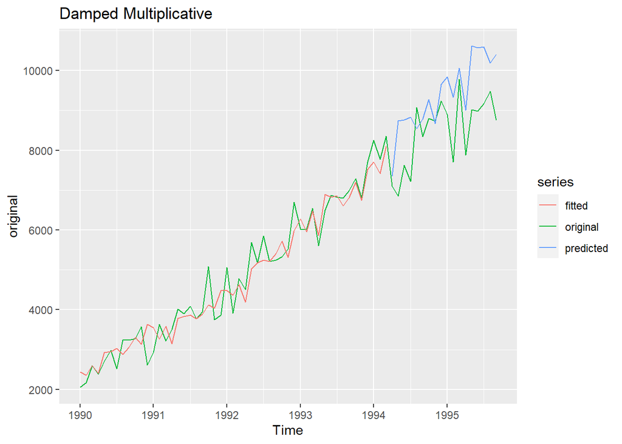

```r
original <- ts(c(df.Train,df.Test), start=start(df.Train), frequency=frequency(df.Train))

autoplot(original, series = "original") +
autolayer(df.hwMultiDamped$fitted, series = "fitted") +
autolayer(df.hwMultiDamped$mean, series = "predicted") +
ggtitle("Damped Multiplicative")
```

## Comparison with simple model (THIS)

The performance indicators in the table above ilustrate that the damped holts-Winter method outperformes the simple mode on the training set. Surprisingly, the Simple Model performs better than Exponential Smoothing Models on the test data. This is surprising, since Simple Models are normally only applicable for very simple models and short prediction intervals.

```r
accDf <- rbind(
  accuracy(naive_shipment, df.Test),
  accuracy(df.hwMultiDamped, df.Test) #Anpassung des Models
)
rownames(accDf) <- c("Naive Model - Training", "Naive Model - Test", "hw damped Multiplicative - Training", "hw damped Multiplicative - Training")

accDf[, c(2:3)]
```

[output not shown]

```r
#accuracy(naive_shipment, df.Test)  #da chunt dis beste model ine
#accuracy(df.hwMultiDamped, df.Test)
```

Since we have already stated in the previous chapter that the chosen time series is too complex for simple models, we can conclude that exponential smoothings models are not suitable either. Since the Exponential Smoothing Models performed even worse in our test.

# ETS AND AUTO-ARIMA (Kevin)

## Fitting

#### ETS

```r
df.ets <- ets(df.Train)
summary(df.ets)
```

```
## ETS(A,A,N)
##
## Call:
##  ets(y = df.Train)
##
##   Smoothing parameters:
##     alpha = 0.0214
##     beta  = 0.0214
##
##   Initial states:
##     l = 2177.7851
##     b = 77.8987
##
##   sigma:  419.3386
##
##      AIC     AICc      BIC
## 822.3027 823.6361 831.9619
##
## Training set error measures:
##                    ME     RMSE      MAE       MPE    MAPE      MASE       ACF1
## Training set 80.73092 402.5582 316.9789 0.8628456 7.31002 0.2358294 -0.1799548
```

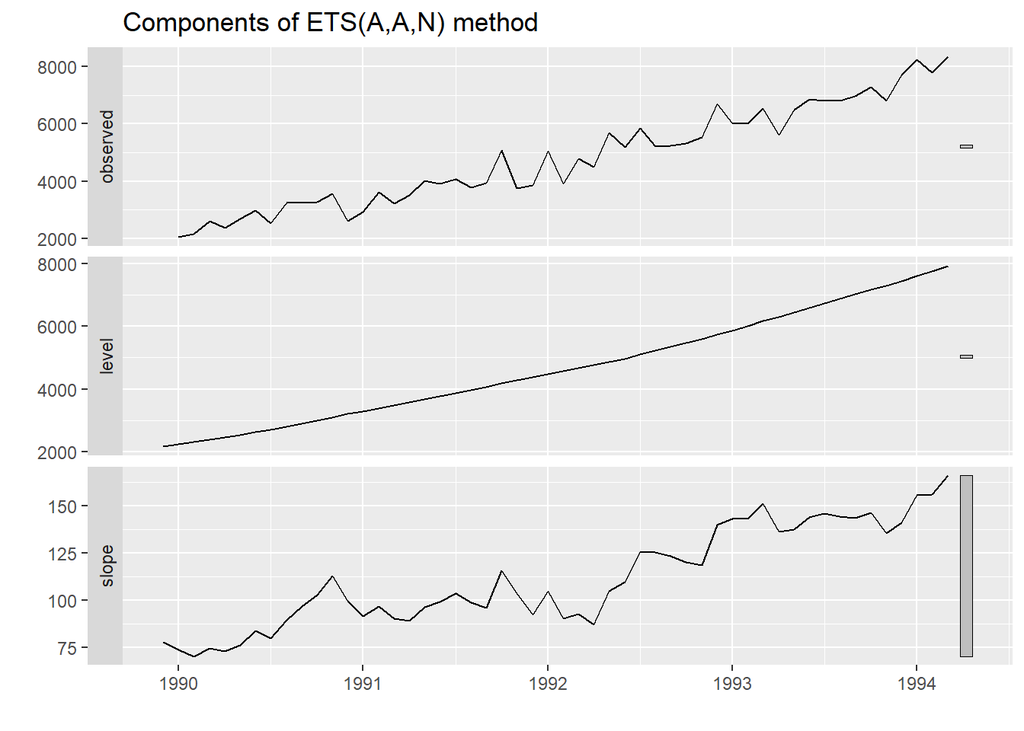

```r
autoplot(df.ets)
```

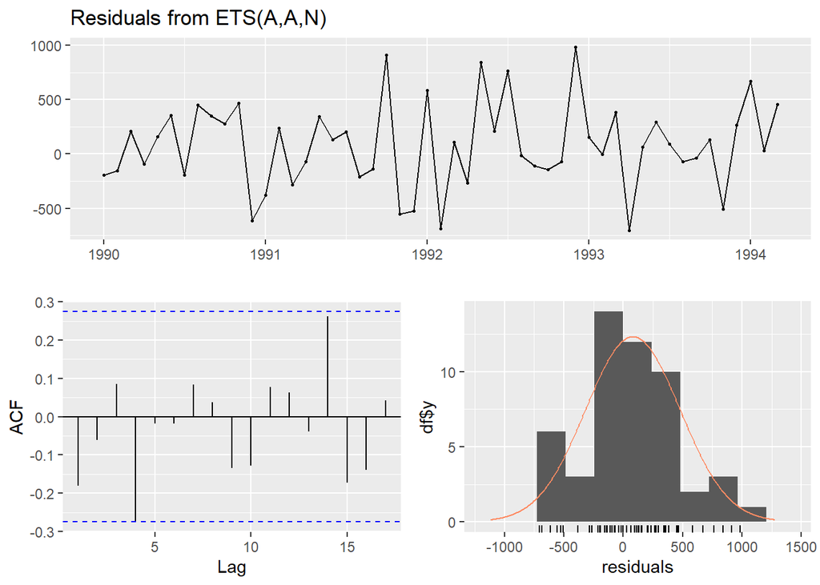

```
##
##  Ljung-Box test
##
## data:  Residuals from ETS(A,A,N)
## Q* = 9.5401, df = 6, p-value = 0.1454
##
## Model df: 4.   Total lags used: 10
```

```r
checkresiduals(df.ets)
```

#### auto.arima

The data doesn’t seem to have changing variance and therefore the log10 transformation is not used.

```r
df.autoarima <- auto.arima(df.Train)
summary(df.autoarima)
```

```
## Series: df.Train
## ARIMA(0,1,1) with drift
##
## Coefficients:
##           ma1     drift
##       -0.8696  115.5011
## s.e.   0.0849    9.3001
##
## sigma^2 = 189095:  log likelihood = -374.38
## AIC=754.76   AICc=755.29   BIC=760.5
##
## Training set error measures:
##                     ME     RMSE      MAE       MPE     MAPE      MASE
## Training set -4.482698 421.8673 325.1873 -1.376498 7.360849 0.2419364
##                    ACF1
## Training set -0.1346102
```

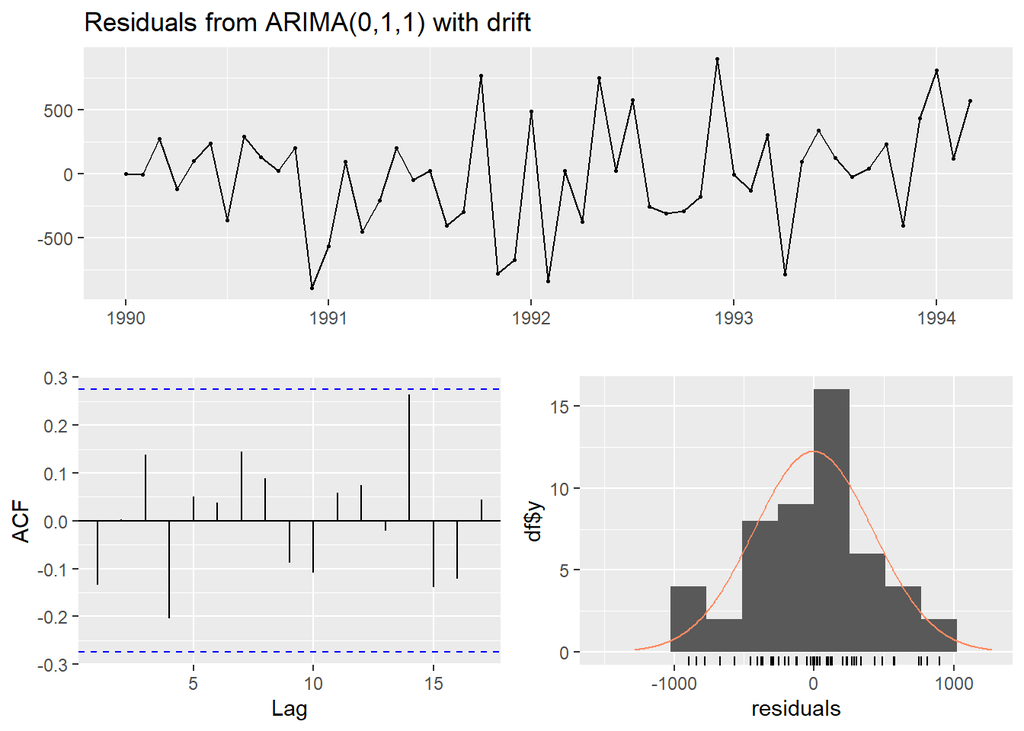

```
##
##  Ljung-Box test
##
## data:  Residuals from ARIMA(0,1,1) with drift
## Q* = 7.7275, df = 9, p-value = 0.5618
##
## Model df: 1.   Total lags used: 10
```

```r
checkresiduals(df.autoarima)
```

The p-value is >> 0.5 and the AFC doesnt show any correlation which is good. The Residual spread looks normal with no clear bias visible.

## Perfomance analysis

### Test set

```r
df.etsFor <- df.ets %>% forecast(h=18)
df.autoarimaFor <- df.autoarima %>% forecast(h=18)

accDf <- rbind(
  accuracy(df.etsFor$mean, df.Test),
  accuracy(df.autoarimaFor$mean, df.Test)
)
rownames(accDf) <- c("ets", "autoarima")

print(accDf)
```

```
##                   ME      RMSE       MAE        MPE      MAPE         ACF1
## ets       -1011.4171 1231.0338 1047.5889 -12.392496 12.791304 -0.009823566
## autoarima  -483.2715  798.6903  661.7872  -6.320769  8.238942 -0.181147399
##           Theil's U
## ets       1.1682043
## autoarima 0.7750191
```

As we can see from the forecasting accuracy (MAE) on the test set, the autoarima model shows a better result than the ets approach by almost 400 error units.

Nevertheless, a better approach to choose the forecasting model is to run a crossvalidation with the original data containing train and test set.